# Planejamento e Análise de Experimentos I

Author

Affiliation

[Prof. Dr. Juliano Bortolini](http://www.julianobortolini.com.br)

Universidade Federal de Mato Grosso

*Bacharelado em Estatística - UFMT*

# Delineamento em Blocos Casualizados (DBC) e Delineamento em Quadrado Latino (DQL)

O problema central de DBC e DQL é o **controle local**. Em experimentos reais, as unidades experimentais raramente são homogêneas. Em campo agrícola, pode haver gradiente de fertilidade, umidade, inclinação ou luminosidade. Em experimentos com animais, pode haver diferenças de idade, peso, sexo, condição fisiológica, leitegada, baia ou período. Se essa heterogeneidade não for controlada, parte da variação ambiental entra no erro experimental e aumenta o quadrado médio do resíduo.

Os três princípios básicos envolvidos são:

- **Repetição**: permite estimar a variabilidade experimental.
- **Casualização**: protege contra vieses sistemáticos de alocação.
- **Controle local**: agrupa unidades semelhantes em blocos ou controla fontes conhecidas de variação.

A ideia matemática é retirar do resíduo uma fonte sistemática de variação que não interessa diretamente ao pesquisador. Assim, se a blocagem for eficiente, o erro experimental diminui e o teste para tratamentos ganha precisão. O custo é a perda de graus de liberdade do resíduo, pois blocos, linhas e colunas também entram como fontes de variação na ANOVA.

Do ponto de vista de planejamento experimental, a decisão mais importante é reconhecer se a heterogeneidade é:

- **ausente ou desprezível**: pode-se usar delineamento inteiramente casualizado;
- **dominante em uma direção ou fator**: o DBC costuma ser adequado;
- **dominante em duas direções ou fatores cruzados**: o DQL pode ser adequado, desde que suas restrições sejam viáveis.

O pesquisador deve lembrar que a casualização não corrige um delineamento mal escolhido. A aleatorização protege contra vieses de alocação, mas o controle local precisa ser coerente com a estrutura real da variabilidade.

## Delineamento em Blocos Casualizados (DBC)

O DBC, também chamado de delineamento em blocos ao acaso ou blocos completos casualizados, é usado quando existe **uma fonte principal de heterogeneidade** a controlar. Cada bloco deve ser internamente homogêneo e deve conter todos os tratamentos.

Se há $I$ tratamentos e $J$ blocos, o número total de observações é:

$$N = IJ$$

Cada tratamento aparece uma vez em cada bloco no DBC completo sem repetição intra-bloco.

**Modelo linear aditivo**

$$Y_{ij} = \mu + \tau_i + \beta_j + \varepsilon_{ij},
\qquad i = 1,\ldots,I,\quad j = 1,\ldots,J$$

em que:

- $Y_{ij}$ é a resposta do tratamento $i$ no bloco $j$;
- $\mu$ é a média geral;
- $\tau_i$ é o efeito do tratamento $i$;
- $\beta_j$ é o efeito do bloco $j$;
- $\varepsilon_{ij}$ é o erro aleatório.

Usualmente impõem-se as restrições:

$$\sum_{i=1}^{J}\tau_i = 0,
\qquad
\sum_{j=1}^{J}\beta_j = 0.$$

Os pressupostos clássicos são:

$$\varepsilon_{ij} \overset{iid}{\sim} N(0,\sigma^2),$$

com independência, normalidade, homogeneidade de variâncias e aditividade. A aditividade significa que não há interação tratamento-bloco no modelo. Como há apenas uma observação por combinação tratamento-bloco, uma interação real não pode ser estimada separadamente e tende a contaminar o resíduo.

**Decomposição da soma de quadrados**

Defina:

$$G = \sum_{i=1}^{I}\sum_{j=1}^{J}Y_{ij},
\qquad
C = \frac{G^2}{IJ},$$

$$T_i = \sum_{j=1}^{J}Y_{ij},
\qquad
B_j = \sum_{i=1}^{I}Y_{ij}.$$

A soma de quadrados total é:

$$SQ_{Total} = \sum_{i=1}^{I}\sum_{j=1}^{J}Y_{ij}^2 - C.$$

A soma de quadrados de tratamentos é:

$$SQ_{Trat} = \frac{1}{J}\sum_{i=1}^{I}T_i^2 - C.$$

A soma de quadrados de blocos é:

$$SQ_{Blocos} = \frac{1}{I}\sum_{j=1}^{J}B_j^2 - C.$$

A soma de quadrados do resíduo é obtida por diferença:

$$SQ_E = SQ_{Total} - SQ_{Trat} - SQ_{Blocos}.$$

A identidade por médias mostra o porquê da decomposição:

$$Y_{ij}-\bar{Y}_{..}
=
(\bar{Y}_{i.}-\bar{Y}_{..})
+
(\bar{Y}_{.j}-\bar{Y}_{..})
+
(Y_{ij}-\bar{Y}_{i.}-\bar{Y}_{.j}+\bar{Y}_{..}).$$

Em delineamento balanceado, os três componentes são ortogonais, permitindo separar tratamento, bloco e erro.

**Tabela ANOVA do DBC**

| Fonte de variação | GL | SQ | QM | F |
| --- | --- | --- | --- | --- |
| Tratamentos | $I-1$ | $SQ_{Trat}$ | $QM_{Trat}=\dfrac{SQ_{Trat}}{I-1}$ | $\dfrac{QM_{Trat}}{QM_E}$ |
| Blocos | $J-1$ | $SQ_{Blocos}$ | $QM_{Blocos}=\dfrac{SQ_{Blocos}}{J-1}$ | $\dfrac{QM_{Blocos}}{QM_E}$ |
| Erro | $(I-1)(J-1)$ | $SQ_E$ | $QM_E=\dfrac{SQ_E}{(I-1)(J-1)}$ |  |
| Total | $IJ-1$ | $SQ_{Total}$ |  |  |

O teste principal é:

$$H_0:\tau_1=\tau_2=\cdots=\tau_I=0$$

contra

$$H_1:\text{pelo menos um efeito de tratamento difere de zero.}$$

Rejeita-se $H_0$ se:

$$F_{calc} = \frac{QM_{Trat}}{QM_E}
>
F_{1-\alpha;\,I-1,\,(I-1)(J-1)}.$$

### Planejamento prático do DBC

No DBC, a qualidade estatística do experimento depende da qualidade dos blocos. Um bloco deve ser formado por unidades experimentais que sejam tão semelhantes quanto possível quanto à fonte de variação que se deseja controlar. Entre blocos, pode haver grande heterogeneidade; dentro de blocos, não.

Exemplos de variáveis usadas para formar blocos:

- fertilidade do solo;
- declividade;
- umidade;
- distância a uma bordadura;
- idade de animais;
- peso inicial;
- leitegada;
- lote de matéria-prima;
- dia de execução;
- operador;
- laboratório;
- avaliador;
- período de medição.

A pergunta operacional é:

$$\text{Dentro de cada bloco, consigo comparar todos os tratamentos em condições semelhantes?}$$

Se a resposta for sim, o DBC é uma boa opção. Se o bloco não comporta todos os tratamentos, o delineamento passa a ser de blocos incompletos, que exige outra análise. Se há duas fontes cruzadas de variação igualmente importantes, o DQL pode ser mais apropriado.

### Aleatorização dos tratamentos no DBC

No DBC completo, a aleatorização é feita **separadamente dentro de cada bloco**. Essa é uma restrição deliberada: não se sorteiam todos os tratamentos em todas as parcelas do experimento como se fosse DIC; sorteia-se uma permutação dos tratamentos para cada bloco.

Procedimento manual:

1. Defina os tratamentos: por exemplo, $A$, $B$, $C$, $D$.
2. Defina os blocos: por exemplo, $B_1,\ldots,B_6$.
3. Em cada bloco, numere as parcelas de $1$ a $a$.
4. Para o bloco $B_1$, sorteie uma ordem aleatória dos $a$ tratamentos.
5. Repita o sorteio de forma independente para $B_2,\ldots,B_b$.
6. Registre o croqui antes da instalação do experimento.

Com $a$ tratamentos, há $a!$ possíveis ordens dentro de cada bloco. Com $b$ blocos, se os sorteios forem independentes, há:

$$(a!)^b$$

possíveis alocações no DBC completo.

Exemplo de uma aleatorização possível para $4$ tratamentos e $6$ blocos:

| Bloco | Parcela 1 | Parcela 2 | Parcela 3 | Parcela 4 |
| --- | --- | --- | --- | --- |
| 1 | A | D | C | B |
| 2 | A | C | D | B |
| 3 | D | A | C | B |
| 4 | B | D | C | A |
| 5 | C | A | B | D |
| 6 | D | B | C | A |

Esse croqui preserva a exigência fundamental: em cada bloco, todos os tratamentos aparecem uma vez.

Código R para gerar uma casualização DBC:

```r
set.seed(2026)

tratamentos <- LETTERS[1:4]
n_blocos <- 6

random_dbc <- do.call(
  rbind,
  lapply(seq_len(n_blocos), function(j) {
    data.frame(
      bloco = paste0("Bloco_", j),
      parcela_no_bloco = seq_along(tratamentos),
      tratamento = sample(tratamentos)
    )
  })
)

random_dbc
```

```
     bloco parcela_no_bloco tratamento
1  Bloco_1                1          A
2  Bloco_1                2          D
3  Bloco_1                3          C
4  Bloco_1                4          B
5  Bloco_2                1          A
6  Bloco_2                2          C
7  Bloco_2                3          D
8  Bloco_2                4          B
9  Bloco_3                1          D
10 Bloco_3                2          A
11 Bloco_3                3          C
12 Bloco_3                4          B
13 Bloco_4                1          B
14 Bloco_4                2          D
15 Bloco_4                3          C
16 Bloco_4                4          A
17 Bloco_5                1          C
18 Bloco_5                2          A
19 Bloco_5                3          B
20 Bloco_5                4          D
21 Bloco_6                1          D
22 Bloco_6                2          B
23 Bloco_6                3          C
24 Bloco_6                4          A
```

Para formar um croqui no formato de matriz, útil em campo:

```r
matrix(
  random_dbc$tratamento,
  nrow = n_blocos,
  byrow = TRUE,
  dimnames = list(paste0("Bloco_", 1:n_blocos), paste0("Parcela_", 1:4))
)
```

```
        Parcela_1 Parcela_2 Parcela_3 Parcela_4
Bloco_1 "A"       "D"       "C"       "B"
Bloco_2 "A"       "C"       "D"       "B"
Bloco_3 "D"       "A"       "C"       "B"
Bloco_4 "B"       "D"       "C"       "A"
Bloco_5 "C"       "A"       "B"       "D"
Bloco_6 "D"       "B"       "C"       "A"
```

### Erros comuns no DBC

- Formar blocos grandes demais, tornando as parcelas internas heterogêneas.
- Confundir bloco com repetição quando há mais de uma repetição de tratamento dentro de bloco.
- Sortear tratamentos uma única vez e repetir a mesma ordem em todos os blocos sem justificativa operacional.
- Usar blocos para controlar uma característica que não está relacionada à resposta.
- Ignorar a estrutura de blocos na análise, ajustando um modelo como se os dados fossem inteiramente casualizados.
- Usar muitos tratamentos em cada bloco quando a homogeneidade dentro do bloco deixa de ser plausível.

### Diagnóstico após a ANOVA no DBC

Após ajustar o modelo, não basta olhar o valor de $F$. É necessário verificar:

- resíduos versus valores ajustados, para avaliar homogeneidade de variância;
- gráfico quantil-quantil dos resíduos, para avaliar normalidade aproximada;
- resíduos por bloco, para detectar blocos problemáticos;
- resíduos por tratamento, para detectar tratamentos com variância discrepante;
- coerência agronômica, biológica ou operacional dos efeitos estimados.

Em R:

```r
# Usando um objeto ajustado por aov, por exemplo: modelo_dbc
# par(mfrow = c(2, 2))
# plot(modelo_dbc)
```

O diagnóstico gráfico não substitui o conhecimento experimental. Um resíduo extremo deve ser investigado no caderno de campo, nos registros laboratoriais ou nos metadados de coleta.

## Delineamento em Quadrado Latino (DQL)

O DQL é usado quando existem **duas fontes de heterogeneidade** a controlar. Essas fontes são representadas por linhas e colunas. Cada tratamento aparece exatamente uma vez em cada linha e exatamente uma vez em cada coluna.

Se há $p$ tratamentos, o quadrado latino tem:

$$p \text{ linhas},\quad p \text{ colunas},\quad p \text{ tratamentos},\quad p^2 \text{ observações}.$$

Cada tratamento é repetido $p$ vezes.

**Modelo linear aditivo**

$$Y_{ijk} = \mu + \rho_i + \kappa_j + \tau_k + \varepsilon_{ijk},$$

em que:

- $\rho_i$ é o efeito da linha $i$;
- $\kappa_j$ é o efeito da coluna $j$;
- $\tau_k$ é o efeito do tratamento $k$;
- $Y_{ijk}$ é a observação na linha $i$, coluna $j$, recebendo tratamento $k$.

Como cada célula recebe apenas um tratamento, dois índices localizam a observação; o terceiro é determinado pelo arranjo latino.

As restrições usuais são:

$$\sum_{i=1}^{p}\rho_i=0,
\qquad
\sum_{j=1}^{p}\kappa_j=0,
\qquad
\sum_{k=1}^{p}\tau_k=0.$$

Os pressupostos são:

$$\varepsilon_{ijk}\overset{iid}{\sim}N(0,\sigma^2),$$

com independência, normalidade, homogeneidade de variâncias e aditividade. No DQL, a aditividade é ainda mais crítica, pois não há graus de liberdade para estimar interações linha-tratamento, coluna-tratamento ou linha-coluna de forma ordinária.

**Somas de quadrados**

Defina:

$$G = \sum Y_{ijk},
\qquad
C = \frac{G^2}{p^2}.$$

Sejam $L_i$, $C_j$ e $T_k$ os totais de linhas, colunas e tratamentos, respectivamente. Então:

$$SQ_{Total} = \sum Y_{ijk}^2 - C,$$

$$SQ_{Linhas} = \frac{1}{p}\sum_{i=1}^{p}L_i^2 - C,$$

$$SQ_{Colunas} = \frac{1}{p}\sum_{j=1}^{p}C_j^2 - C,$$

$$SQ_{Trat} = \frac{1}{p}\sum_{k=1}^{p}T_k^2 - C,$$

$$SQ_E = SQ_{Total} - SQ_{Linhas} - SQ_{Colunas} - SQ_{Trat}.$$

O resíduo estimado por célula é:

$$e_{ijk}
=
Y_{ijk}
-\bar{Y}_{i..}
-\bar{Y}_{.j.}
-\bar{Y}_{..k}
+2\bar{Y}_{...}.$$

**Tabela ANOVA do DQL**

| Fonte de variação | GL | SQ | QM | F |
| --- | --- | --- | --- | --- |
| Linhas | $p-1$ | $SQ_{Linhas}$ | $QM_L=\dfrac{SQ_{Linhas}}{p-1}$ | $\dfrac{QM_L}{QM_E}$ |
| Colunas | $p-1$ | $SQ_{Colunas}$ | $QM_C=\dfrac{SQ_{Colunas}}{p-1}$ | $\dfrac{QM_C}{QM_E}$ |
| Tratamentos | $p-1$ | $SQ_{Trat}$ | $QM_T=\dfrac{SQ_{Trat}}{p-1}$ | $\dfrac{QM_T}{QM_E}$ |
| Erro | $(p-1)(p-2)$ | $SQ_E$ | $QM_E=\dfrac{SQ_E}{(p-1)(p-2)}$ |  |
| Total | $p^2-1$ | $SQ_{Total}$ |  |  |

A hipótese principal é:

$$H_0:\tau_1=\tau_2=\cdots=\tau_p=0.$$

Rejeita-se $H_0$ se:

$$F_{calc}
=
\frac{QM_T}{QM_E}
>
F_{1-\alpha;\,p-1,\,(p-1)(p-2)}.$$

O DQL deve ser usado com cautela quando $p$ é pequeno:

| Ordem do QL | GL do erro |
| --- | --- |
| $3\times3$ | 2 |
| $4\times4$ | 6 |
| $5\times5$ | 12 |
| $6\times6$ | 20 |

Por isso, materiais da pasta recomendam atenção especial a QL $3\times3$ e $4\times4$, com alternativas como replicar quadrados latinos ou usar arranjos maiores quando possível.

### Planejamento prático do DQL

O DQL é apropriado quando a unidade experimental pode ser classificada simultaneamente por dois critérios de controle local. Exemplos:

- linha = animal, coluna = período;
- linha = operador, coluna = máquina;
- linha = lote de matéria-prima, coluna = operador;
- linha = faixa de fertilidade norte-sul, coluna = faixa de fertilidade leste-oeste;
- linha = provador, coluna = ordem de degustação;
- linha = sala, coluna = horário;
- linha = paciente, coluna = período terapêutico, quando houver resposta reversível e período de lavagem adequado.

A exigência estrutural é forte:

$$\#\text{linhas} = \#\text{colunas} = \#\text{tratamentos} = p.$$

Além disso:

$$\text{cada tratamento aparece uma vez em cada linha e uma vez em cada coluna.}$$

Essa propriedade é o que torna tratamentos ortogonais às duas fontes de controle local. Se o pesquisador quebrar essa regra, o delineamento deixa de ser um quadrado latino e a ANOVA clássica não se aplica.

### Aleatorização dos tratamentos no DQL

No DQL, a casualização não é uma permutação livre das $p^2$ parcelas. Uma permutação livre poderia colocar o mesmo tratamento duas vezes em uma linha ou coluna. A aleatorização deve preservar a restrição latina.

Um procedimento prático é:

1. Escolha um quadrado latino padrão de ordem $p$.
2. Sorteie aleatoriamente a ordem das linhas.
3. Sorteie aleatoriamente a ordem das colunas.
4. Sorteie aleatoriamente a correspondência entre letras e tratamentos reais.
5. Se houver múltiplos quadrados latinos, sorteie também a ordem ou a estrutura dos quadrados usados.
6. Execute as observações em ordem operacionalmente viável, evitando introduzir confundimento adicional com horário, operador ou sequência de coleta.

Exemplo de quadrado latino padrão $5\times5$:

| Linha/Coluna | C1 | C2 | C3 | C4 | C5 |
| --- | --- | --- | --- | --- | --- |
| L1 | A | B | C | D | E |
| L2 | B | C | D | E | A |
| L3 | C | D | E | A | B |
| L4 | D | E | A | B | C |
| L5 | E | A | B | C | D |

Após aleatorizar linhas, colunas e rótulos de tratamentos, uma possibilidade é:

| Linha/Coluna | C1 | C2 | C3 | C4 | C5 |
| --- | --- | --- | --- | --- | --- |
| L1 | C | E | D | A | B |
| L2 | E | D | A | B | C |
| L3 | A | B | C | E | D |
| L4 | D | A | B | C | E |
| L5 | B | C | E | D | A |

Esse segundo quadro continua sendo um quadrado latino: cada letra aparece uma vez em cada linha e uma vez em cada coluna.

Código R para gerar e aleatorizar um DQL:

```r
set.seed(2026)

p <- 5
trat <- LETTERS[1:p]

ql_padrao <- outer(seq_len(p), seq_len(p), function(i, j) {
  trat[((i + j - 2) %% p) + 1]
})

ql_padrao
```

```
     [,1] [,2] [,3] [,4] [,5]
[1,] "A"  "B"  "C"  "D"  "E"
[2,] "B"  "C"  "D"  "E"  "A"
[3,] "C"  "D"  "E"  "A"  "B"
[4,] "D"  "E"  "A"  "B"  "C"
[5,] "E"  "A"  "B"  "C"  "D"
```

```r
linhas_sorteadas <- sample(seq_len(p))
colunas_sorteadas <- sample(seq_len(p))
rotulos_sorteados <- setNames(sample(trat), trat)

ql_aleatorizado <- ql_padrao[linhas_sorteadas, colunas_sorteadas]
ql_aleatorizado <- matrix(rotulos_sorteados[ql_aleatorizado], nrow = p)

ql_aleatorizado
```

```
     [,1] [,2] [,3] [,4] [,5]
[1,] "E"  "C"  "D"  "A"  "B"
[2,] "C"  "A"  "B"  "D"  "E"
[3,] "B"  "E"  "A"  "C"  "D"
[4,] "A"  "D"  "E"  "B"  "C"
[5,] "D"  "B"  "C"  "E"  "A"
```

Verificação da propriedade latina:

```r
apply(ql_aleatorizado, 1, function(x) sort(x))
```

```
     [,1] [,2] [,3] [,4] [,5]
[1,] "A"  "A"  "A"  "A"  "A"
[2,] "B"  "B"  "B"  "B"  "B"
[3,] "C"  "C"  "C"  "C"  "C"
[4,] "D"  "D"  "D"  "D"  "D"
[5,] "E"  "E"  "E"  "E"  "E"
```

```r
apply(ql_aleatorizado, 2, function(x) sort(x))
```

```
     [,1] [,2] [,3] [,4] [,5]
[1,] "A"  "A"  "A"  "A"  "A"
[2,] "B"  "B"  "B"  "B"  "B"
[3,] "C"  "C"  "C"  "C"  "C"
[4,] "D"  "D"  "D"  "D"  "D"
[5,] "E"  "E"  "E"  "E"  "E"
```

### Aleatorização quando linhas ou colunas são períodos

Quando colunas representam períodos, a aleatorização precisa ser compatível com a cronologia. Não se pode simplesmente executar o período 5 antes do período 1 se o desenho pressupõe seguimento temporal. Nesses casos:

- sorteia-se a sequência de tratamentos dentro das restrições do QL;
- respeita-se a ordem real dos períodos;
- insere-se período de adaptação ou lavagem quando houver efeito residual;
- registra-se qualquer perda de unidade experimental, especialmente em animais ou sujeitos humanos.

Em experimentos com animais, os materiais destacam que, se um animal morre no meio do experimento, o DQL pode ser inviabilizado, pois o mesmo animal deveria continuar nos períodos seguintes. Perdas no último período são menos graves e podem ser analisadas por modelos lineares gerais, mas a ANOVA balanceada clássica deixa de ser literalmente a mesma.

### Erros comuns no DQL

- Usar DQL apenas porque parece sofisticado, mesmo existindo só uma fonte de heterogeneidade.
- Usar $p=3$ ou $p=4$ sem considerar que o erro terá poucos graus de liberdade.
- Desrespeitar a regra de uma ocorrência por linha e por coluna.
- Não controlar efeito residual entre períodos.
- Tratar linhas e colunas como fatores de interesse primário quando elas são apenas controles locais.
- Ignorar que não há replicação dentro de célula para estimar interações.
- Confundir quadrado latino com uma tabela qualquer de tratamentos.

### Diagnóstico após a ANOVA no DQL

Além dos diagnósticos usuais de resíduos, no DQL deve-se verificar:

- se todas as linhas contêm todos os tratamentos uma vez;
- se todas as colunas contêm todos os tratamentos uma vez;
- se a ordem temporal não produziu efeito residual;
- se alguma linha ou coluna tem comportamento incompatível com a hipótese de aditividade;
- se o erro tem graus de liberdade suficientes para inferência confiável.

Em R:

```r
# Usando um objeto ajustado por aov, por exemplo: modelo_dql
# par(mfrow = c(2, 2))
# plot(modelo_dql)
```

# Diferenças entre DBC e DQL

| Aspecto | DBC | DQL |
| --- | --- | --- |
| Fonte de controle local | Uma fonte de variação, representada por blocos | Duas fontes de variação, representadas por linhas e colunas |
| Estrutura | Cada bloco contém todos os tratamentos | Cada tratamento aparece uma vez em cada linha e uma vez em cada coluna |
| Número de tratamentos | Flexível | Igual ao número de linhas e colunas |
| Número de observações | $IJ$ | $p^2$ |
| Repetições por tratamento | $J$ | $p$ |
| GL do erro | $(I-1)(J-1)$ | $(p-1)(p-2)$ |
| Casualização | Independente dentro de cada bloco | Restrita: deve preservar a estrutura latina |
| Uso típico | Campo agrícola com um gradiente dominante; animais agrupados por peso, idade, baia; laboratório por lote | Dois gradientes de campo; animal e período; máquina e dia; avaliador e ordem de prova |
| Principal vantagem | Simples, flexível e geralmente eficiente se os blocos forem homogêneos | Controla simultaneamente duas fontes de heterogeneidade |
| Principal limitação | Perde GL para blocos e exige homogeneidade dentro de blocos | Muito restritivo; poucos GL de erro em quadrados pequenos; exige aditividade forte |

A escolha entre DBC e DQL depende da estrutura da heterogeneidade. Se há apenas um gradiente relevante, o DBC é mais simples e mais flexível. Se há duas fontes fortes e cruzadas de variação, o DQL pode reduzir muito o erro experimental, mas só é adequado se o pesquisador puder respeitar a exigência de número igual de tratamentos, linhas e colunas.

Critérios objetivos de decisão:

| Pergunta | Se a resposta for sim | Delineamento mais provável |
| --- | --- | --- |
| Há apenas uma fonte clara de heterogeneidade? | Sim | DBC |
| Cada bloco comporta todos os tratamentos? | Sim | DBC completo |
| Há duas fontes cruzadas de heterogeneidade? | Sim | DQL |
| O número de tratamentos é igual ao número de níveis das duas fontes de controle? | Sim | DQL possível |
| Há muitos tratamentos e blocos pequenos? | Sim | DBC pode ser inviável; considerar blocos incompletos |
| O mesmo animal, sujeito, máquina ou lote será observado em períodos sucessivos? | Sim | DQL ou desenho de medidas repetidas, com atenção a efeito residual |
| Há forte suspeita de interação tratamento-bloco, tratamento-linha ou tratamento-coluna? | Sim | DBC/DQL aditivos podem ser insuficientes |
| Os tratamentos têm efeito permanente ou destrutivo sobre a unidade? | Sim | Evitar DQL com períodos no mesmo indivíduo |

Em termos de precisão, o controle local é vantajoso quando:

$$QM_E(\text{com controle local}) < QM_E(\text{sem controle local})$$

em magnitude suficiente para compensar a perda de graus de liberdade. Se os blocos, linhas ou colunas não explicam variabilidade relevante, o pesquisador paga o custo em graus de liberdade sem ganhar precisão.

# Exemplos Práticos

Os exemplos abaixo têm duas naturezas:

- **extraídos ou diretamente ancorados nos materiais**: aparecem nos PDFs como exemplos, croquis, aplicações ou exercícios;
- **exemplos de planejamento alinhados à teoria**: não usam dados inventados, mas mostram como aplicar DBC ou DQL em diferentes áreas.

Em todos eles, a pergunta central é: qual fonte de variação será controlada pelo delineamento?

## Exemplos de uso do DBC

### DBC 1: bananeira cv. Nanicão

Banzatto & Kronka apresentam um planejamento em bananeira cv. Nanicão para avaliar sistemas de condução baseados no número e época de manutenção de rebentos. O delineamento é em blocos casualizados com 8 tratamentos e 5 repetições. Cada parcela tem 10 touceiras, espaçadas em $2{,}5 \times 2{,}0$ m, com área de $50\,m^2$. O experimento totaliza:

$$8 \times 5 = 40 \text{ parcelas}$$

e

$$40 \times 10 = 400 \text{ plantas}.$$

O esquema de ANOVA é:

| Fonte | GL |
| --- | --- |
| Tratamentos | 7 |
| Blocos | 4 |
| Resíduo | 28 |
| Total | 39 |

Aleatorização: em cada um dos 5 blocos, os 8 sistemas de condução são sorteados nas 8 parcelas. A ordem sorteada em um bloco não precisa coincidir com a ordem dos demais blocos.

### DBC 2: cultivares de cana-de-açúcar

Os materiais usam o exemplo de competição de cultivares de cana-de-açúcar em blocos casualizados. Suponha 5 cultivares e 5 blocos.

| Elemento | Definição |
| --- | --- |
| Tratamentos | Cultivares de cana |
| Unidade experimental | Parcela de campo |
| Blocos | Faixas homogêneas de solo |
| Resposta | Produtividade, teor de açúcar, biomassa |
| Aleatorização | Sorteio das 5 cultivares dentro de cada bloco |

Esse exemplo é típico de DBC porque uma faixa de solo pode ser mais fértil que outra. A comparação entre cultivares deve ocorrer dentro de cada faixa homogênea.

### DBC 3: fontes ou doses de adubação em soja

| Elemento | Definição |
| --- | --- |
| Tratamentos | Doses ou fontes de adubo |
| Unidade experimental | Parcela de soja |
| Blocos | Faixas de fertilidade ou declividade |
| Resposta | Produtividade, massa de grãos, teor foliar |
| Justificativa | O solo é heterogêneo em uma direção dominante |

Aleatorização: se houver 6 doses e 4 blocos, cada bloco recebe as 6 doses em ordem sorteada. A ANOVA terá $5$ GL para tratamentos, $3$ GL para blocos e $15$ GL para erro.

### DBC 4: inseticidas no controle de pragas

| Elemento | Definição |
| --- | --- |
| Tratamentos | Inseticidas ou doses |
| Unidade experimental | Parcela infestada |
| Blocos | Faixas com nível inicial semelhante de infestação |
| Resposta | Número de insetos, dano foliar, produtividade |
| Justificativa | A infestação inicial pode variar no campo |

Esse caso se conecta diretamente ao princípio de casualização discutido nos materiais: sem sorteio, um inseticida poderia parecer melhor apenas por ter sido alocado em parcelas menos infestadas.

### DBC 5: métodos de semeadura de mamoeiro

Banzatto & Kronka apresentam exemplo com métodos de semeadura de mamoeiro. Em planejamento DBC, os tratamentos podem ser métodos de formação de mudas ou semeadura direta, e os blocos controlam heterogeneidade ambiental entre áreas.

| Elemento | Definição |
| --- | --- |
| Tratamentos | Métodos de semeadura ou formação de mudas |
| Unidade experimental | Parcela com plantas de mamoeiro |
| Blocos | Faixas homogêneas de campo |
| Resposta | Altura, sobrevivência, desenvolvimento inicial |
| Aleatorização | Sorteio dos métodos dentro de cada bloco |

### DBC 6: irrigação em cultura anual

| Elemento | Definição |
| --- | --- |
| Tratamentos | Lâminas de irrigação |
| Unidade experimental | Parcela irrigada |
| Blocos | Posição no campo ou faixa de textura do solo |
| Resposta | Produtividade, eficiência do uso da água |
| Risco sem blocagem | Confundir efeito da lâmina com capacidade de retenção de água |

### DBC 7: competição de cultivares de milho

| Elemento | Definição |
| --- | --- |
| Tratamentos | Cultivares ou híbridos |
| Unidade experimental | Parcela de milho |
| Blocos | Gradiente de fertilidade, umidade ou declividade |
| Resposta | Produtividade, altura de plantas, acamamento |
| Aleatorização | Cada cultivar sorteada uma vez dentro de cada bloco |

Esse é um dos usos mais clássicos do DBC em experimentação agronômica.

### DBC 8: correção do solo e calagem

| Elemento | Definição |
| --- | --- |
| Tratamentos | Doses de calcário ou corretivos |
| Unidade experimental | Parcela agrícola |
| Blocos | Faixas com pH ou saturação por bases semelhantes |
| Resposta | pH final, produtividade, disponibilidade de nutrientes |
| Justificativa | A fertilidade inicial do solo pode gerar variação sistemática |

### DBC 9: rações para suínos

Sonia Vieira apresenta exemplo de blocos completos com suínos agrupados por peso. O raciocínio é:

| Elemento | Definição |
| --- | --- |
| Tratamentos | Promotores de crescimento ou rações |
| Unidade experimental | Animal ou baia |
| Blocos | Grupos de suínos com pesos iniciais próximos |
| Resposta | Ganho de peso, conversão alimentar |
| Aleatorização | Sorteio dos tratamentos dentro de cada grupo de peso |

O peso inicial é uma fonte forte de variação. Bloquear por peso evita comparar uma ração aplicada a animais maiores com outra aplicada a animais menores.

### DBC 10: nutrição de aves

| Elemento | Definição |
| --- | --- |
| Tratamentos | Níveis de proteína, energia ou aditivo |
| Unidade experimental | Boxe com aves |
| Blocos | Fileiras do galpão ou posição em relação à ventilação |
| Resposta | Ganho de peso, consumo, conversão alimentar |
| Justificativa | Temperatura e ventilação variam dentro do galpão |

### DBC 11: aquicultura

| Elemento | Definição |
| --- | --- |
| Tratamentos | Dietas, densidades de estocagem ou probióticos |
| Unidade experimental | Tanque ou viveiro |
| Blocos | Setor do sistema hidráulico ou gradiente de renovação de água |
| Resposta | Crescimento, sobrevivência, conversão alimentar |
| Aleatorização | Tratamentos sorteados entre tanques dentro de cada setor |

### DBC 12: bovinos leiteiros com blocos por produção inicial

| Elemento | Definição |
| --- | --- |
| Tratamentos | Suplementos alimentares |
| Unidade experimental | Vaca ou grupo de vacas |
| Blocos | Produção pré-experimental, ordem de parto ou estágio de lactação |
| Resposta | Produção de leite, composição do leite |
| Justificativa | Animais com maior produção inicial tendem a manter maior produção |

Quando a mesma vaca recebe vários tratamentos em períodos sucessivos, o delineamento pode migrar para DQL ou medidas repetidas. Se cada animal recebe apenas um tratamento, o DBC por produção inicial é mais simples.

### DBC 13: avaliação sensorial de cafés

Sonia Vieira apresenta exemplo de prova de xícara com degustadores como blocos.

| Elemento | Definição |
| --- | --- |
| Tratamentos | Tipos de café |
| Unidade experimental | Amostra servida ao degustador |
| Blocos | Degustadores |
| Resposta | Nota sensorial |
| Aleatorização | Ordem dos cafés sorteada separadamente para cada degustador |

Esse exemplo é muito importante didaticamente: o degustador é uma fonte de variação, pois alguns avaliadores tendem a dar notas maiores ou menores. Bloquear por degustador melhora a comparação entre cafés.

### DBC 14: vinhos avaliados por juízes

| Elemento | Definição |
| --- | --- |
| Tratamentos | Vinhos, safras ou métodos de vinificação |
| Unidade experimental | Taça codificada |
| Blocos | Juízes |
| Resposta | Nota global, aroma, acidez, corpo |
| Aleatorização | Cada juiz recebe os vinhos em ordem sorteada |

Quando a ordem de prova também é importante, pode-se considerar DQL com juiz e ordem como controles.

### DBC 15: ensaio clínico bloqueado por estágio da doença

Taback discute blocagem em estudos com pacientes por estágio da doença. Em um DBC ou randomização em blocos:

| Elemento | Definição |
| --- | --- |
| Tratamentos | Terapias ou doses |
| Unidade experimental | Paciente |
| Blocos | Estágio da doença, centro clínico ou faixa de risco |
| Resposta | Sobrevida, resposta clínica, biomarcador |
| Aleatorização | Sorteio dos tratamentos dentro de cada estrato |

A blocagem impede que um tratamento receba, por acaso, maior proporção de pacientes em estágio mais leve.

### DBC 16: dermatologia com lesões no mesmo paciente

| Elemento | Definição |
| --- | --- |
| Tratamentos | Cremes, pomadas ou curativos |
| Unidade experimental | Lesão ou área cutânea |
| Blocos | Paciente |
| Resposta | Redução da lesão, escore inflamatório |
| Justificativa | Pacientes diferem em genética, imunidade e hábitos |

Cada paciente pode receber todos os tratamentos em regiões comparáveis, com sorteio da alocação dentro de paciente.

### DBC 17: oftalmologia com olhos pareados

| Elemento | Definição |
| --- | --- |
| Tratamentos | Colírios ou procedimentos |
| Unidade experimental | Olho |
| Blocos | Paciente |
| Resposta | Pressão intraocular, acuidade, inflamação |
| Aleatorização | Sorteio de qual olho recebe qual tratamento |

Com dois tratamentos e dois olhos, o DBC se aproxima de um delineamento pareado.

### DBC 18: indústria têxtil com rolos de tecido

Montgomery apresenta exercícios e exemplos de blocagem com materiais. Um planejamento típico:

| Elemento | Definição |
| --- | --- |
| Tratamentos | Produtos químicos, acabamentos ou processos |
| Unidade experimental | Amostra de tecido |
| Blocos | Rolo ou lote de tecido |
| Resposta | Resistência, encolhimento, cor |
| Aleatorização | Aplicar todos os tratamentos em ordem sorteada dentro de cada rolo |

O rolo é bloco porque amostras do mesmo rolo são mais semelhantes entre si do que amostras de rolos diferentes.

### DBC 19: indústria química com lotes de matéria-prima

| Elemento | Definição |
| --- | --- |
| Tratamentos | Catalisadores, temperaturas ou formulações |
| Unidade experimental | Batelada experimental |
| Blocos | Lote de matéria-prima |
| Resposta | Rendimento, pureza, tempo de reação |
| Justificativa | Lotes de matéria-prima podem ter composição ligeiramente diferente |

### DBC 20: laboratório analítico com operadores

| Elemento | Definição |
| --- | --- |
| Tratamentos | Métodos analíticos |
| Unidade experimental | Amostra analisada |
| Blocos | Operador ou dia |
| Resposta | Concentração estimada, erro, tempo de análise |
| Aleatorização | Ordem dos métodos sorteada dentro de operador ou dia |

Se operador e dia forem simultaneamente importantes e tiverem o mesmo número de níveis que os métodos, pode-se considerar DQL.

### DBC 21: educação com escolas como blocos

| Elemento | Definição |
| --- | --- |
| Tratamentos | Métodos de ensino |
| Unidade experimental | Turma |
| Blocos | Escola ou faixa de desempenho inicial |
| Resposta | Ganho em teste padronizado |
| Justificativa | Escolas diferem em infraestrutura e perfil socioeconômico |

### DBC 22: psicologia experimental com sujeitos como blocos

| Elemento | Definição |
| --- | --- |
| Tratamentos | Interfaces, estímulos ou tarefas |
| Unidade experimental | Sessão/tarefa aplicada a um sujeito |
| Blocos | Sujeito |
| Resposta | Tempo de reação, acurácia, escore |
| Aleatorização | Ordem dos estímulos sorteada dentro de sujeito |

Se a ordem da tarefa é uma segunda fonte importante, um DQL com sujeito e ordem pode ser mais adequado.

### DBC 23: ciência ambiental com transectos

| Elemento | Definição |
| --- | --- |
| Tratamentos | Métodos de recuperação ambiental |
| Unidade experimental | Parcela em área degradada |
| Blocos | Transectos com condições semelhantes |
| Resposta | Cobertura vegetal, erosão, biodiversidade |
| Aleatorização | Tratamentos sorteados dentro de cada transecto |

### DBC 24: armazenamento pós-colheita

| Elemento | Definição |
| --- | --- |
| Tratamentos | Embalagens ou atmosferas de armazenamento |
| Unidade experimental | Lote de frutos |
| Blocos | Dia de colheita ou talhão de origem |
| Resposta | Perda de massa, firmeza, teor de sólidos solúveis |
| Justificativa | Frutos colhidos em dias ou talhões diferentes podem ter maturação distinta |

## Exemplos de uso do DQL

### DQL 1: cinco tratamentos em cinco animais e cinco períodos

O exemplo numérico de *Estatística experimental na agropecuária* usa 5 animais nas linhas, 5 períodos nas colunas e 5 tratamentos. Cada animal recebe todos os tratamentos uma vez ao longo dos períodos, e cada período contém todos os tratamentos uma vez.

| Elemento | Definição |
| --- | --- |
| Linhas | Animais |
| Colunas | Períodos |
| Tratamentos | A, B, C, D, E |
| Resposta | Medida biológica ou produtiva |
| Restrição | Evitar efeito residual entre períodos |

### DQL 2: cana-de-açúcar com dois gradientes no campo

Sonia Vieira apresenta exemplo conceitual de quadrado latino em agricultura para variedades de cana-de-açúcar sob duas direções de heterogeneidade.

| Elemento | Definição |
| --- | --- |
| Linhas | Faixas em uma direção do campo |
| Colunas | Faixas na direção perpendicular |
| Tratamentos | Variedades ou fórmulas de fertilização |
| Resposta | Produtividade, teor de açúcar |
| Justificativa | Fertilidade ou umidade variam em duas direções |

### DQL 3: adubação em soja

Banzatto & Kronka citam experimento em quadrado latino com 5 níveis de adubação para soja.

| Elemento | Definição |
| --- | --- |
| Linhas | Gradiente de solo 1 |
| Colunas | Gradiente de solo 2 |
| Tratamentos | 5 níveis de adubação |
| Resposta | Produtividade da soja |
| ANOVA | Tratamentos, linhas, colunas, resíduo |

### DQL 4: casa de vegetação com luz e temperatura

| Elemento | Definição |
| --- | --- |
| Linhas | Faixas de luminosidade |
| Colunas | Faixas de temperatura ou ventilação |
| Tratamentos | Substratos, doses ou cultivares |
| Resposta | Crescimento, massa seca, área foliar |
| Justificativa | Bancadas de casa de vegetação frequentemente têm gradientes cruzados |

### DQL 5: vacas leiteiras, rações e períodos

| Elemento | Definição |
| --- | --- |
| Linhas | Vacas |
| Colunas | Períodos |
| Tratamentos | Rações ou suplementos |
| Resposta | Produção de leite, gordura, proteína |
| Cuidados | Período pré-experimental e período de lavagem |

Esse é um caso clássico quando os animais são caros e poucos. A repetição no tempo compensa a baixa disponibilidade de unidades, mas exige resposta reversível.

### DQL 6: equinos com suplementos

| Elemento | Definição |
| --- | --- |
| Linhas | Animais |
| Colunas | Períodos de avaliação |
| Tratamentos | Suplementos ou dietas |
| Resposta | Desempenho, frequência cardíaca, recuperação |
| Restrição | Não usar se o tratamento tiver efeito permanente prolongado |

### DQL 7: avaliação sensorial com provadores e ordem de apresentação

| Elemento | Definição |
| --- | --- |
| Linhas | Provadores |
| Colunas | Ordem de degustação |
| Tratamentos | Amostras de café, vinho, queijo ou suco |
| Resposta | Nota sensorial |
| Justificativa | Controla diferenças entre provadores e efeito de ordem/fadiga |

O DBC com provador como bloco controla apenas diferença entre provadores. O DQL controla também a posição da amostra na sequência de degustação.

### DQL 8: indústria com formulações, lotes e operadores

Montgomery apresenta a lógica de DQL com formulações de propelente, lotes de matéria-prima e operadores.

| Elemento | Definição |
| --- | --- |
| Linhas | Lotes ou bateladas de matéria-prima |
| Colunas | Operadores |
| Tratamentos | Formulações |
| Resposta | Taxa de queima, rendimento, pureza |
| Justificativa | Controla duas fontes de variação de processo |

### DQL 9: máquinas, dias e operadores

Sonia Vieira apresenta exemplo em que operadores, máquinas e dias da semana aparecem em arranjo de quadrado latino.

| Elemento | Definição |
| --- | --- |
| Linhas | Máquinas |
| Colunas | Dias |
| Tratamentos | Operadores ou métodos operacionais |
| Resposta | Itens produzidos, defeitos, tempo de ciclo |
| Justificativa | Máquinas e dias podem afetar produção |

### DQL 10: laboratório com métodos, técnicos e dias

| Elemento | Definição |
| --- | --- |
| Linhas | Técnicos |
| Colunas | Dias |
| Tratamentos | Métodos de análise |
| Resposta | Erro analítico, recuperação, tempo |
| Aleatorização | Cada método aparece uma vez por técnico e uma vez por dia |

### DQL 11: estudo de interfaces com usuários e ordem de uso

| Elemento | Definição |
| --- | --- |
| Linhas | Usuários |
| Colunas | Ordem da tarefa |
| Tratamentos | Interfaces ou layouts |
| Resposta | Tempo de conclusão, erro, satisfação |
| Justificativa | Controla diferenças entre usuários e efeito de aprendizagem/fadiga |

### DQL 12: educação com turmas e semanas

| Elemento | Definição |
| --- | --- |
| Linhas | Turmas |
| Colunas | Semanas ou módulos |
| Tratamentos | Estratégias didáticas |
| Resposta | Desempenho em avaliações curtas |
| Cuidados | Evitar aprendizagem cumulativa que contamine tratamentos seguintes |

Se o efeito de uma estratégia de ensino persistir por muitas semanas, o DQL pode ser inadequado.

### DQL 13: fisiologia do exercício

| Elemento | Definição |
| --- | --- |
| Linhas | Atletas |
| Colunas | Sessões |
| Tratamentos | Protocolos de aquecimento |
| Resposta | Potência, tempo, frequência cardíaca |
| Cuidados | Intervalo suficiente entre sessões |

### DQL 14: agricultura de precisão com talhão em duas direções

| Elemento | Definição |
| --- | --- |
| Linhas | Faixas por coordenada norte-sul |
| Colunas | Faixas por coordenada leste-oeste |
| Tratamentos | Doses de insumo ou cultivares |
| Resposta | Produtividade georreferenciada |
| Justificativa | Controla variação espacial em duas direções |

### DQL 15: armazenamento com câmaras e períodos

| Elemento | Definição |
| --- | --- |
| Linhas | Câmaras ou prateleiras |
| Colunas | Períodos |
| Tratamentos | Embalagens ou atmosferas |
| Resposta | Perda de massa, firmeza, cor |
| Cuidados | Tratamentos destrutivos não devem voltar à mesma unidade |

### DQL 16: odontologia com materiais restauradores

| Elemento | Definição |
| --- | --- |
| Linhas | Pacientes ou blocos dentários comparáveis |
| Colunas | Posição ou período |
| Tratamentos | Materiais restauradores |
| Resposta | Resistência, desgaste, sensibilidade |
| Cuidados | A resposta precisa ser comparável entre posições ou períodos |

### DQL 17: avaliação de fragrâncias no varejo

| Elemento | Definição |
| --- | --- |
| Linhas | Lojas |
| Colunas | Horários ou dias |
| Tratamentos | Fragrâncias ambientais |
| Resposta | Tempo de permanência, vendas, avaliação do consumidor |
| Justificativa | Controla diferenças entre lojas e horários |

### DQL 18: testes de software com avaliadores e ordem de tarefa

| Elemento | Definição |
| --- | --- |
| Linhas | Avaliadores |
| Colunas | Ordem de execução |
| Tratamentos | Versões de interface, fluxos ou ferramentas |
| Resposta | Tempo, erro, carga cognitiva |
| Justificativa | Controla habilidade individual e efeito de aprendizagem |

## Comparação didática dos exemplos

| Situação | Melhor candidato | Por quê |
| --- | --- | --- |
| Cultivares em faixas de solo | DBC | Uma fonte dominante: fertilidade |
| Cultivares em dois gradientes cruzados | DQL | Duas fontes espaciais |
| Cafés avaliados por degustadores | DBC | Degustador é bloco |
| Cafés avaliados com efeito de ordem | DQL | Degustador e ordem são controles |
| Rações com animais agrupados por peso | DBC | Peso inicial é uma fonte |
| Rações nos mesmos animais ao longo de períodos | DQL | Animal e período são controles |
| Formulações com lote de matéria-prima | DBC | Lote é bloco |
| Formulações com lote e operador | DQL | Duas fontes de variação |
| Terapias em pacientes estratificados por estágio | DBC | Estágio é bloco/estrato |
| Tratamentos reversíveis aplicados em sujeitos e períodos | DQL | Sujeito e período são controles |

# Resolução de Exercícios

**Exercício 1: DBC com Promalin em macieira**

Dados extraídos de Banzatto & Kronka. O experimento avaliou 5 tratamentos de aplicação de Promalin em macieiras, com 4 blocos. A resposta é o peso médio dos frutos, em gramas.

| Tratamento | Bloco 1 | Bloco 2 | Bloco 3 | Bloco 4 | Total |
| --- | --- | --- | --- | --- | --- |
| 1 | 142,4 | 144,8 | 145,2 | 138,9 | 571,3 |
| 2 | 139,3 | 137,8 | 144,4 | 130,6 | 552,1 |
| 3 | 140,7 | 134,1 | 136,1 | 144,1 | 555,0 |
| 4 | 150,9 | 135,8 | 137,0 | 136,4 | 560,1 |
| 5 | 153,5 | 165,0 | 151,8 | 150,2 | 620,5 |
| Total dos blocos | 726,8 | 717,5 | 714,5 | 700,2 | 2859,0 |

Temos:

$$I=5,\quad J=4,\quad N=20,\quad G=2859{,}0.$$

O fator de correção é:

$$C = \frac{G^2}{N}
=
\frac{2859^2}{20}
=
408694{,}05.$$

A soma dos quadrados das observações é:

$$\sum y_{ij}^2 = 409966{,}36.$$

Logo:

$$SQ_{Total}
=
409966{,}36 - 408694{,}05
=
1272{,}31.$$

Para tratamentos:

$$SQ_{Trat}
=
\frac{1}{4}
(571{,}3^2+552{,}1^2+555{,}0^2+560{,}1^2+620{,}5^2)
-408694{,}05
=
794{,}79.$$

Para blocos:

$$SQ_{Blocos}
=
\frac{1}{5}
(726{,}8^2+717{,}5^2+714{,}5^2+700{,}2^2)
-408694{,}05
=
72{,}91.$$

Para o resíduo:

$$SQ_E
=
1272{,}31-794{,}79-72{,}91
=
404{,}61.$$

Tabela ANOVA:

| Fonte | GL | SQ | QM | $F_{calc}$ | $F_{5\%}$ | $F_{1\%}$ | Decisão |
| --- | --- | --- | --- | --- | --- | --- | --- |
| Tratamentos | 4 | 794,79 | 198,70 | 5,89 | 3,26 | 5,41 | Significativo a 1% |
| Blocos | 3 | 72,91 | 24,30 | 0,72 | 3,49 | 5,95 | Não significativo |
| Resíduo | 12 | 404,61 | 33,72 |  |  |  |  |
| Total | 19 | 1272,31 |  |  |  |  |  |

Conclusão: como

$$F_{Trat}=5{,}89 > F_{0{,}99;4,12}=5{,}41,$$

rejeita-se $H_0$ para tratamentos ao nível de 1%. Há evidência de que as formas de aplicação do Promalin alteram o peso médio dos frutos. Para blocos,

$$F_{Blocos}=0{,}72 < F_{0{,}95;3,12}=3{,}49,$$

não há evidência estatística de efeito de blocos nesse conjunto.

Código R executável:

```r
promalin <- data.frame(
  trat = factor(rep(1:5, each = 4)),
  bloco = factor(rep(1:4, times = 5)),
  y = c(
    142.4, 144.8, 145.2, 138.9,
    139.3, 137.8, 144.4, 130.6,
    140.7, 134.1, 136.1, 144.1,
    150.9, 135.8, 137.0, 136.4,
    153.5, 165.0, 151.8, 150.2
  )
)

modelo_dbc <- aov(y ~ trat + bloco, data = promalin)
anova(modelo_dbc)
```

```
Analysis of Variance Table

Response: y
          Df Sum Sq Mean Sq F value   Pr(>F)
trat       4 794.79 198.697  5.8929 0.007334 **
bloco      3  72.91  24.302  0.7207 0.558616
Residuals 12 404.61  33.718
---
Signif. codes:  0 '***' 0.001 '**' 0.01 '*' 0.05 '.' 0.1 ' ' 1
```

```r
qf(0.95, df1 = 4, df2 = 12)
```

```
[1] 3.259167
```

```r
qf(0.99, df1 = 4, df2 = 12)
```

```
[1] 5.411951
```

```r
qf(0.95, df1 = 3, df2 = 12)
```

```
[1] 3.490295
```

```r
qf(0.99, df1 = 3, df2 = 12)
```

```
[1] 5.952545
```

```r
TukeyHSD(modelo_dbc, "trat")
```

```
  Tukey multiple comparisons of means
    95% family-wise confidence level

Fit: aov(formula = y ~ trat + bloco, data = promalin)

$trat
      diff         lwr       upr     p adj
2-1 -4.800 -17.8874729  8.287473 0.7680505
3-1 -4.075 -17.1624729  9.012473 0.8537704
4-1 -2.800 -15.8874729 10.287473 0.9566831
5-1 12.300  -0.7874729 25.387473 0.0691173
3-2  0.725 -12.3624729 13.812473 0.9997480
4-2  2.000 -11.0874729 15.087473 0.9871214
5-2 17.100   4.0125271 30.187473 0.0093768
4-3  1.275 -11.8124729 14.362473 0.9976843
5-3 16.375   3.2875271 29.462473 0.0126749
5-4 15.100   2.0125271 28.187473 0.0215966
```

```r
cv_dbc <- 100 * sqrt(deviance(modelo_dbc) / df.residual(modelo_dbc)) / mean(promalin$y)
cv_dbc
```

```
[1] 4.062054
```

O coeficiente de variação é:

$$CV = 100\frac{\sqrt{QM_E}}{\bar{Y}_{..}}
=
100\frac{\sqrt{33{,}72}}{142{,}95}
=
4{,}06\%.$$

**Exercício 2: DQL 5 x 5 com animais e períodos**

Dados extraídos de *Estatística experimental na agropecuária*. Há 5 animais, 5 períodos e 5 tratamentos. A resposta é fictícia, usada para ilustrar a análise.

| Animal | Período 1 | Período 2 | Período 3 | Período 4 | Período 5 |
| --- | --- | --- | --- | --- | --- |
| 1 | B = 164 | D = 161 | A = 149 | C = 157 | E = 164 |
| 2 | E = 168 | B = 171 | D = 162 | A = 152 | C = 152 |
| 3 | C = 153 | E = 152 | B = 172 | D = 163 | A = 153 |
| 4 | D = 160 | A = 148 | C = 159 | E = 160 | B = 171 |
| 5 | A = 145 | C = 155 | E = 145 | B = 169 | D = 153 |

Aqui:

$$p=5,\quad N=25,\quad G=3958.$$

O fator de correção é:

$$C = \frac{3958^2}{25}=626630{,}56.$$

A soma dos quadrados das observações é:

$$\sum y^2 = 628226.$$

Assim:

$$SQ_{Total}=628226-626630{,}56=1595{,}44.$$

Totais de linhas:

$$L=(795,805,793,798,767).$$

Logo:

$$SQ_{Linhas}
=
\frac{1}{5}(795^2+805^2+793^2+798^2+767^2)-626630{,}56
=
167{,}84.$$

Totais de colunas:

$$C_j=(790,787,787,801,793).$$

Logo:

$$SQ_{Colunas}
=
27{,}04.$$

Totais de tratamentos:

$$T_A=747,\quad T_B=847,\quad T_C=776,\quad T_D=799,\quad T_E=789.$$

Logo:

$$SQ_{Trat}
=
\frac{1}{5}(747^2+847^2+776^2+799^2+789^2)-626630{,}56
=
1072{,}64.$$

O resíduo é:

$$SQ_E
=
1595{,}44-167{,}84-27{,}04-1072{,}64
=
327{,}92.$$

Tabela ANOVA:

| Fonte | GL | SQ | QM | $F_{calc}$ | $F_{5\%}$ | $F_{1\%}$ | Decisão |
| --- | --- | --- | --- | --- | --- | --- | --- |
| Linhas | 4 | 167,84 | 41,96 | 1,54 | 3,26 | 5,41 | Não significativo |
| Colunas | 4 | 27,04 | 6,76 | 0,25 | 3,26 | 5,41 | Não significativo |
| Tratamentos | 4 | 1072,64 | 268,16 | 9,81 | 3,26 | 5,41 | Significativo a 1% |
| Erro | 12 | 327,92 | 27,33 |  |  |  |  |
| Total | 24 | 1595,44 |  |  |  |  |  |

Conclusão: como

$$F_{Trat}=9{,}81 > F_{0{,}99;4,12}=5{,}41,$$

rejeita-se $H_0$ ao nível de 1%. Há diferença estatisticamente significativa entre tratamentos. Linhas e colunas não foram significativas nesse exemplo, mas continuam fazendo parte do delineamento porque são restrições de controle local.

Código R executável:

```r
ql5x5 <- data.frame(
  animal = factor(rep(1:5, each = 5)),
  periodo = factor(rep(1:5, times = 5)),
  trat = factor(c(
    "B", "D", "A", "C", "E",
    "E", "B", "D", "A", "C",
    "C", "E", "B", "D", "A",
    "D", "A", "C", "E", "B",
    "A", "C", "E", "B", "D"
  )),
  y = c(
    164, 161, 149, 157, 164,
    168, 171, 162, 152, 152,
    153, 152, 172, 163, 153,
    160, 148, 159, 160, 171,
    145, 155, 145, 169, 153
  )
)

modelo_dql <- aov(y ~ animal + periodo + trat, data = ql5x5)
anova(modelo_dql)
```

```
Analysis of Variance Table

Response: y
          Df  Sum Sq Mean Sq F value    Pr(>F)
animal     4  167.84  41.960  1.5355 0.2538682
periodo    4   27.04   6.760  0.2474 0.9057535
trat       4 1072.64 268.160  9.8131 0.0009217 ***
Residuals 12  327.92  27.327
---
Signif. codes:  0 '***' 0.001 '**' 0.01 '*' 0.05 '.' 0.1 ' ' 1
```

```r
qf(0.95, df1 = 4, df2 = 12)
```

```
[1] 3.259167
```

```r
qf(0.99, df1 = 4, df2 = 12)
```

```
[1] 5.411951
```

```r
TukeyHSD(modelo_dql, "trat")
```

```
  Tukey multiple comparisons of means
    95% family-wise confidence level

Fit: aov(formula = y ~ animal + periodo + trat, data = ql5x5)

$trat
     diff         lwr        upr     p adj
B-A  20.0   9.4618521 30.5381479 0.0004511
C-A   5.8  -4.7381479 16.3381479 0.4401654
D-A  10.4  -0.1381479 20.9381479 0.0536735
E-A   8.4  -2.1381479 18.9381479 0.1452524
C-B -14.2 -24.7381479 -3.6618521 0.0075155
D-B  -9.6 -20.1381479  0.9381479 0.0805851
E-B -11.6 -22.1381479 -1.0618521 0.0288729
D-C   4.6  -5.9381479 15.1381479 0.6440152
E-C   2.6  -7.9381479 13.1381479 0.9297420
E-D  -2.0 -12.5381479  8.5381479 0.9715988
```

```r
cv_dql <- 100 * sqrt(deviance(modelo_dql) / df.residual(modelo_dql)) / mean(ql5x5$y)
cv_dql
```

```
[1] 3.301852
```

As médias dos tratamentos são:

$$\bar{A}=149{,}4,\quad
\bar{B}=169{,}4,\quad
\bar{C}=155{,}2,\quad
\bar{D}=159{,}8,\quad
\bar{E}=157{,}8.$$

Pelo resultado do material, o tratamento B forma o grupo superior; D é intermediário; A, C e E ficam no grupo inferior ou estatisticamente semelhante ao inferior, conforme o teste de Tukey a 5%.

**Exercício 3: construir a aleatorização de um DBC**

Planeje a casualização de um DBC com 4 tratamentos ($A$, $B$, $C$, $D$) e 6 blocos. Cada bloco contém 4 parcelas.

Passo 1: defina o número total de unidades experimentais:

$$N = IJ = 4 \times 6 = 24.$$

Passo 2: dentro de cada bloco, sorteie uma permutação dos 4 tratamentos.

Passo 3: verifique que cada tratamento aparece exatamente uma vez em cada bloco.

Código R:

```r
set.seed(2026)

tratamentos <- c("A", "B", "C", "D")
blocos <- paste0("B", 1:6)

croqui_dbc <- do.call(
  rbind,
  lapply(blocos, function(bl) {
    data.frame(
      bloco = bl,
      parcela = paste0("P", seq_along(tratamentos)),
      tratamento = sample(tratamentos)
    )
  })
)

croqui_dbc
```

```
   bloco parcela tratamento
1     B1      P1          A
2     B1      P2          D
3     B1      P3          C
4     B1      P4          B
5     B2      P1          A
6     B2      P2          C
7     B2      P3          D
8     B2      P4          B
9     B3      P1          D
10    B3      P2          A
11    B3      P3          C
12    B3      P4          B
13    B4      P1          B
14    B4      P2          D
15    B4      P3          C
16    B4      P4          A
17    B5      P1          C
18    B5      P2          A
19    B5      P3          B
20    B5      P4          D
21    B6      P1          D
22    B6      P2          B
23    B6      P3          C
24    B6      P4          A
```

```r
xtabs(~ bloco + tratamento, data = croqui_dbc)
```

```
     tratamento
bloco A B C D
   B1 1 1 1 1
   B2 1 1 1 1
   B3 1 1 1 1
   B4 1 1 1 1
   B5 1 1 1 1
   B6 1 1 1 1
```

Conclusão operacional: a tabela de contingência deve conter apenas valores 1. Isso confirma que, em cada bloco, todos os tratamentos aparecem uma vez.

Se a tabela apresentar valor 0 ou 2 em algum bloco, o croqui não é um DBC completo.

**Exercício 4: construir a aleatorização de um DQL**

Planeje um DQL $5\times5$ para 5 tratamentos ($A$, $B$, $C$, $D$, $E$). Use linhas e colunas como dois controles locais.

Passo 1: comece com um quadrado latino padrão:

$$\begin{matrix}
A & B & C & D & E\\
B & C & D & E & A\\
C & D & E & A & B\\
D & E & A & B & C\\
E & A & B & C & D
\end{matrix}$$

Passo 2: sorteie linhas, colunas e rótulos dos tratamentos.

Passo 3: verifique que cada linha e cada coluna contém os 5 tratamentos uma única vez.

Código R:

```r
set.seed(2026)

p <- 5
trat <- LETTERS[1:p]

ql <- outer(seq_len(p), seq_len(p), function(i, j) {
  trat[((i + j - 2) %% p) + 1]
})

perm_linhas <- sample(seq_len(p))
perm_colunas <- sample(seq_len(p))
perm_trat <- setNames(sample(trat), trat)

ql_rand <- ql[perm_linhas, perm_colunas]
ql_rand <- matrix(perm_trat[ql_rand], nrow = p)

ql_rand
```

```
     [,1] [,2] [,3] [,4] [,5]
[1,] "E"  "C"  "D"  "A"  "B"
[2,] "C"  "A"  "B"  "D"  "E"
[3,] "B"  "E"  "A"  "C"  "D"
[4,] "A"  "D"  "E"  "B"  "C"
[5,] "D"  "B"  "C"  "E"  "A"
```

```r
verifica_linhas <- apply(ql_rand, 1, function(x) length(unique(x)) == p)
verifica_colunas <- apply(ql_rand, 2, function(x) length(unique(x)) == p)

verifica_linhas
```

```
[1] TRUE TRUE TRUE TRUE TRUE
```

```r
verifica_colunas
```

```
[1] TRUE TRUE TRUE TRUE TRUE
```

Conclusão operacional: todos os valores de `verifica_linhas` e `verifica_colunas` devem ser `TRUE`. Isso confirma que a casualização preservou a estrutura latina.

**Exercício 5: decidir entre DBC e DQL**

Para cada situação, indique o delineamento mais adequado:

| Situação | Fonte(s) de heterogeneidade | Delineamento indicado |
| --- | --- | --- |
| 6 cultivares em campo com gradiente de fertilidade em uma direção | Fertilidade | DBC |
| 5 adubos em campo com gradiente norte-sul e leste-oeste | Duas direções do solo | DQL |
| 4 cafés avaliados por 12 degustadores, sem preocupação com ordem | Degustador | DBC |
| 4 cafés avaliados por 4 degustadores em 4 posições de ordem | Degustador e ordem | DQL |
| 5 rações testadas em 5 vacas ao longo de 5 períodos | Animal e período | DQL |
| 5 rações testadas em grupos independentes de animais formados por peso inicial | Peso inicial | DBC |
| 4 formulações testadas em 4 lotes de matéria-prima | Lote | DBC |
| 4 formulações testadas em 4 lotes e 4 operadores | Lote e operador | DQL |

Justificativa: o DBC controla uma fonte de heterogeneidade; o DQL controla duas. Quando houver períodos e tratamentos com possível efeito residual, a decisão estatística deve ser subordinada à viabilidade biológica ou operacional.

**Exercício 6: checar pressupostos nos exemplos ajustados**

Para o DBC de Promalin e o DQL $5\times5$, os modelos ajustados por `aov()` permitem inspeção gráfica dos resíduos:

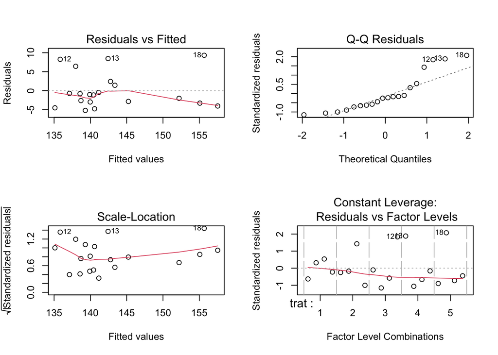

```r
# Diagnóstico do DBC
par(mfrow = c(2, 2))
plot(modelo_dbc)
```

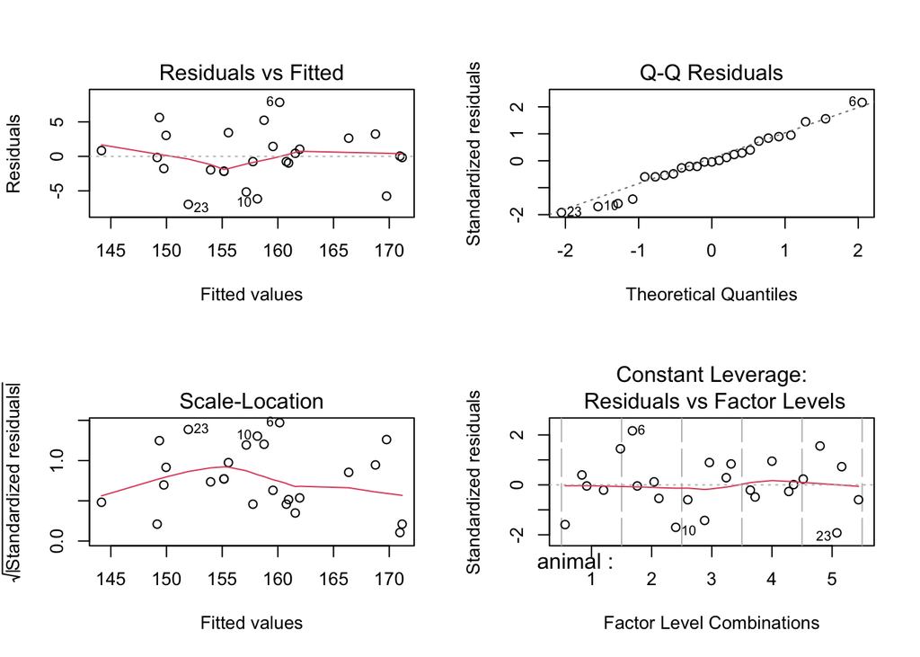

```r
# Diagnóstico do DQL
par(mfrow = c(2, 2))
plot(modelo_dql)
```

```r
par(mfrow = c(1, 1))
```

Interpretação:

- No gráfico resíduos versus ajustados, procura-se ausência de padrão sistemático.
- No Q-Q plot, procura-se aderência aproximada dos resíduos à reta.
- No gráfico escala-localização, procura-se dispersão relativamente constante.
- Pontos extremos devem ser confrontados com anotações de campo ou laboratório.

Se os pressupostos falham fortemente, alternativas incluem transformação da resposta, modelo linear generalizado, modelo misto, análise não paramétrica ou revisão do delineamento.

# Conclusão

DBC e DQL são delineamentos baseados no mesmo princípio: remover do erro experimental fontes conhecidas de variação que não são o foco da pesquisa. O DBC controla uma fonte de heterogeneidade por meio de blocos completos e casualização dentro de cada bloco. O DQL amplia essa lógica para duas direções de controle, usando linhas e colunas ortogonais aos tratamentos.

O ganho de precisão só ocorre quando o controle local realmente reduz a variabilidade residual. Caso contrário, há apenas perda de graus de liberdade. Por isso, a decisão estatística começa antes da ANOVA: começa na identificação correta das fontes de heterogeneidade, na montagem do campo ou laboratório, na casualização e na garantia de que as pressuposições do modelo aditivo são plausíveis.

Em síntese: use DBC quando houver uma fonte dominante de variação a controlar; use DQL quando houver duas fontes cruzadas e fortes de variação, desde que a restrição de número igual de tratamentos, linhas e colunas seja experimentalmente viável. Em ambos os casos, a aleatorização deve respeitar a estrutura do delineamento: no DBC, sorteia-se dentro de blocos; no DQL, sorteiam-se linhas, colunas e rótulos preservando a propriedade latina.